# Day 13–Normal Distribution CLT

## The Normal Distribution

- One continuous probability distribution that comes up often is the **normal distribution**.
  - it is continuous
  - symmetric
  - unimodal (meaning it has one mode, there is a particular value that is a more common than other values)
  - is bell shaped
- many natural processes follow a normal distribution
  - like diameter of tree trunks for a particular tree species
  - height
  - error in a factory
- Consider running a simulation where you take a sample of a fixed size over and over.
- the collection of all your errors will be normally distributed
- the **standard normal distribution** is center at $0$ with standard deviation $1$.
- so changing the population mean will change where the normal distribution is centered
- and a different standard deviation affects how spread out it is.

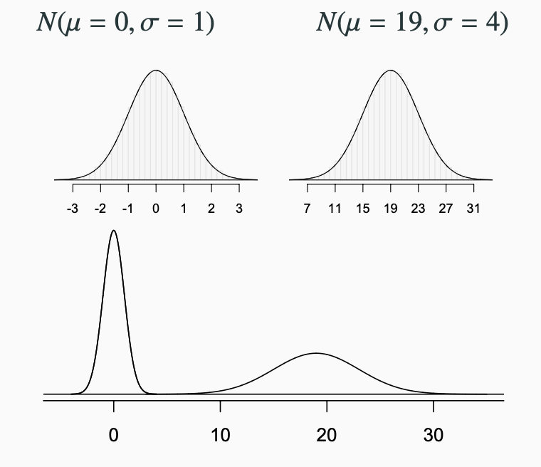

Image source: OpenIntro

### Finding areas

Probability distributions are used to find the probability of certain events occurring, to do this, we need to compute areas.

- eg. Find the probability of a randomly selected observation from a standard normal distribution being less than 1.

```r
pnorm(1)
```

```
## [1] 0.8413447
```

To find the probability that a randomly selected observation being greater than 1 is:

```r
1-pnorm(1)
```

```
## [1] 0.1586553
```

- the `pnorm()` function always gives the area to the left of the input value on a standard normal curve
- to find the area to the right, you need to do `1-pnorm()`

```r
pnorm(1,lower.tail=FALSE)
```

```
## [1] 0.1586553
```

- to find areas for non-standard normal curves first find the z-score and then use the standard normal curve.

```r
z <- (23-19)/4
pnorm(z)
```

```
## [1] 0.8413447
```

Use R to find the area between -1 and 1 on the standard normal curve

```r
pnorm(1)-pnorm(-1)
```

```
## [1] 0.6826895
```

```r
# About 68%
```

Area between -2 and 2

```r
pnorm(2)-pnorm(-2)
```

```
## [1] 0.9544997
```

```r
# About 95%
```

Area between -3 and 3

```r
pnorm(3)-pnorm(-3)
```

```
## [1] 0.9973002
```

```r
# About 99.7%
```

- On the standard normal curve about 68% of observations are within 1 standard deviation of 0.
- 95% are within 2
- 99.7% are within 3 standard deviations
- This is sometimes referred to as the 68-95-99.7 rule
- people use these guidelines even with non-normal distributions.

## Sampling distribution

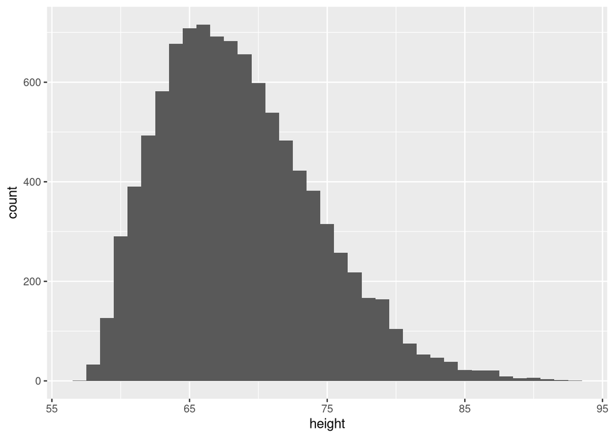

```r
# fake data with some very tall people
fake_data <- data.frame("height" = 57+50*(rbeta(10000,3,10)))
ggplot(fake_data, aes(x=height))+geom_histogram(binwidth = 1)
```

```r
# fake data with some very tall people
# suppose this is the population of interest
mean_height <- mean(fake_data$height)
sd_height <- sd(fake_data$height)
# average height of 68.5
# and standard deviation of 5.6
```

```r
samp_1 <- sample(fake_data$height,50,replace=TRUE)
```

```r
mean(samp_1)
```

```
## [1] 69.96653
```

```r
samp_2 <- sample(fake_data$height,50,replace=TRUE)
```

```r
mean(samp_2)
```

```
## [1] 68.02546
```

## Sampling Distribution

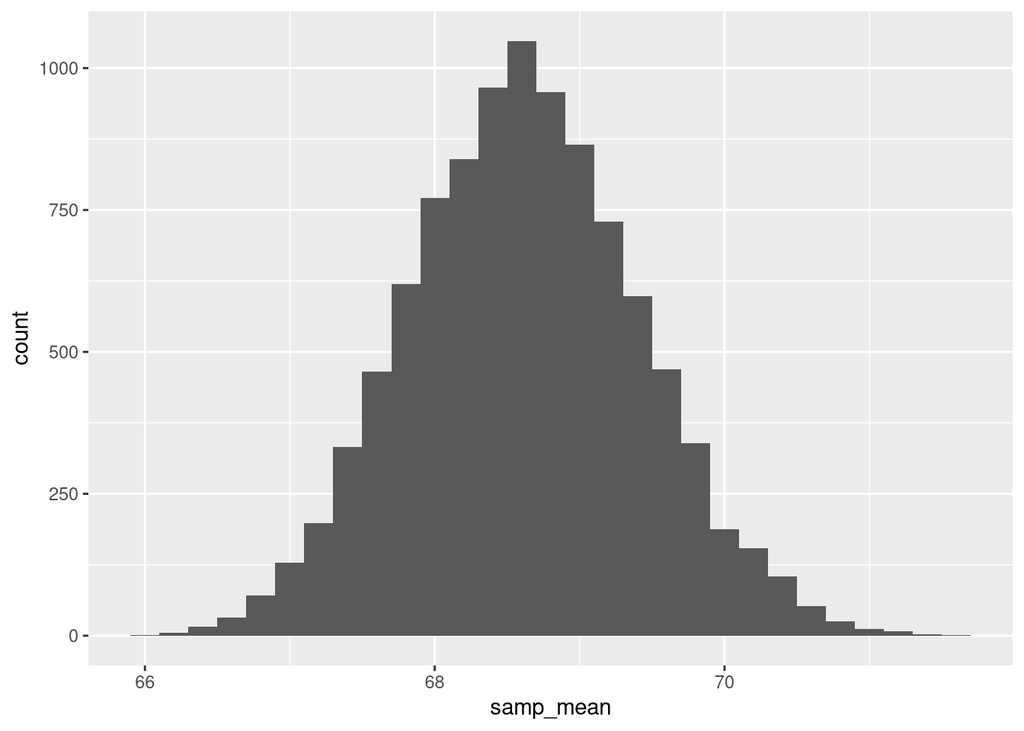

```r
sampling_dist <- data.frame(samp_mean = replicate(10000, mean(sample(sample(fake_data$height,50,replace=TRUE)))))
ggplot(sampling_dist, aes(x=samp_mean))+geom_histogram(binwidth = .2)
```

- we started with a skewed population, it has a mean and standard deviation
- we collected repeated samples of size 50 and looked at the mean in each sample, these are called **sample means**.
- we looked at the distribution of sample means, this is called the **sampling distribution**
- the **central limit theorem** says the sampling distribution will be normal